# A Summary of An Effort to Improve the Practical and Psychometric Properties of Traditional ORF

Joseph F. T. Nese, Ph.D.  
University of Oregon  
jnese@uoregon.edu

## CORE

[**Computerized Oral Reading Evaluation**](https://jnese.github.io/core-blog/)

CORE is a computerized ORF assessment framework that combines multiple shorter passages, automatic speech recognition (ASR) for scoring, and a latent variable psychometric model to produce model-based WCPM scores

Institute of Education Sciences Grant [R305A140203](https://ies.ed.gov/funding/grantsearch/details.asp?ID=1492)

Three CORE research studies

## Purpose

1. Why?
2. How?
3. What?
4. Where?

## Traditional ORF Assessment

- a student reads aloud for 1 min (passage ~250 words)
- an assessor marks each word the student reads incorrectly (including omissions)
- **WCPM** - outcome is **w**ords read **c**orrectly **p**er **m**inute (total words - incorrect words)

## Advantages

- essential part of reading proficiency [1]
- used in classrooms across the U.S.
- quick for one student
- indicator of reading comprehension & general reading achievement [2]–[7]

## Limitations

1. opportunity cost (not quick for many students) [8]
2. administration errors [9]–[12]
3. passage inequivalence [13]
4. score reliability and precision [14], [15]
5. consequential validity [16]

## Limitations 1 & 2

1. opportunity cost
2. administration errors

#### Approach: **ASR**

- groups (or entire classrooms) to be assessed at one time with one educator
- standardized delivery, setting, & scoring
  - timing the reading for exactly 60 s
  - accurately calculating WCPM
  - recording the correct WCPM score

# Study 1

Nese, J. F. T., & Kamata, A. (2021). Evidence for automated scoring and shorter passages of CBM-R in early elementary school. *School Psychology, 36*, 47-59. doi: [10.1037/spq0000415](https://psycnet.apa.org/doiLanding?doi=10.1037%2Fspq0000415)

## What we did

902 students across Grades 2-4 (from 4 schools)

Read 13,766 passages

- 1 Traditional ORF passage (easyCBM)
- 14-18 CORE passages
  - 25-85 words in length (short, medium, long)

Scored by:

- Traditional (human)
- ASR
- Criterion (human)

## We wanted to know

1. Do WCPM scores differ by passage *length* ($\times$ 4)?

### We found

None of the WCPM pairwise comparisons (across grades and scoring methods) between the traditional ORF passages and the shorter CORE passages were statistically significantly different.

The shorter passages read in their entirety functioned similarly to the traditional ORF passages read for 1 min

## We also wanted to know

2. Do **WCPM** scores differ by *scoring method* ($\times$ 3)?

### We found

Human criterion vs:

- **ASR**: all 12 pairwise comparisons statistically different
- **Traditional**: 8 of 12 pairwise comparisons statistically different

ASR and traditional scores were different from criterion scores, but most of these differences were below the “acceptable threshold”[17]

## We also *also* wanted to know

3. Do **word** scores differ by *scoring method* ($\times$ 3)?

### We found

Average agreement rates between the human criterion and:

- **Traditional**: .97 to .99
- **ASR**: .81 to .94 (all but one > .87)

Human-to-ASR degradation from the human-to-human score agreement was generally below the “acceptable threshold” [17]

## Conclusions

- Shorter passages can be used for ORF assessment
- ASR can be used to score ORF assessment
  - ASR applied here is now 6+ years old

# Model-based WCPM

Kara, Y., Kamata, A., Potgieter, C., & Nese, J. F. T. (2020). Estimating model-based oral reading fluency: A Bayesian approach. *Educational and Psychological Measurement, 80*, 847-869. doi: [10.1177/0013164419900208](https://www.ncbi.nlm.nih.gov/pmc/articles/PMC7425326/)

## Model-based WCPM

- Two-part latent-variable psychometric model
- Passages equated, horizontally scaled, and vertically linked
  - scores on a common scale, especially useful for progress monitoring
- Same metric as traditional ORF scores (i.e., WCPM)
  - immediately usable for teachers and reading specialists
- *SE*s computed for each WCPM score (*CSEM*)

## Limitations 3 & 4

3. passage inequivalence
4. score reliability and precision

#### Approach: Model-based WCPM (Kara et al., 2020)

Two-part latent-variable psychometric model (jointly modeled and estimated)

1. Accuracy - binomial-count factor model (number of passage words read correctly)
2. Speed - log-normal factor model (passage reading time)

# Study 2

Nese, J. F. T. & Kamata, A. (2021). Addressing the large standard error of traditional CBM-R: Estimating the conditional standard error of a model-based estimate of CBM-R. *Assessment for Effective Intervention, 47*, 53-58. doi: 10.1177/1534508420937801

## What we did

1,021 students across Grades 2-4 (from 4 schools)

Read 4,084 passages

- 10 to 12 CORE passages (fixed sets randomly assigned)
  - 50-85 words in length (medium or long)
- Across 4 occasions (Oct, Nov, Feb, May)

Scored by ASR

Model-based WCPM scores

## We wanted to know

1. Is the average conditional standard error of measurement (*CSEM*) for the model-based WCPM estimates smaller than the reported *SEM*s of traditional ORF systems?

### We found

| ORF Measure | Grade 2 | Grade 3 | Grade 4 |
| --- | --- | --- | --- |
| **SEM** |  |  |  |
| aimsweb Plus | 7.78 | 7.46 | 8.4 |
| DIBELS 8th Edition | 7.84 | 9.59 | 9.63 |
| easyCBM | -- | 9.73 | -- |
| FastBridge | 8.54 | 8.54 | 10.41 |
| **CSEM** |  |  |  |
| CORE Model-based WCPM | 5.15 | 5.47 | 7.63 |

## We also wanted to know

2. What about for students at/below the 25th percentile?

### We found

| Grade | Unique Students | Number of CBM-R Tests | Percent < 8 WCPM | Mean CSEM |
| --- | --- | --- | --- | --- |
| Grade 2 | 122 | 251 | 99.6 | 3.0 |
| Grade 3 | 127 | 284 | 98.9 | 3.3 |
| Grade 4 | 125 | 253 | 98.0 | 4.8 |

## Conclusions

Preliminary but promising evidence that the model-based WCPM scale scores can increase score reliability and precision

- better identify students at risk of poor reading outcomes
- better determine student responsiveness to intervention

## Limitation 5

5. consequential validity

#### Approach: CORE vs. Traditional ORF

Apply ASR, real-world setting, and model-based WCPM scores and compare growth estimates and predictive performance to Traditional ORF assessment

# Study 3

Nese, J. F. T. (2022). Comparing the Growth and Predictive Performance of a Traditional Oral Reading Fluency Measure With an Experimental Novel Measure. *AERA Open, 8*, 1-19. doi: 10.1177/23328584211071112

## What we did

2,108 students across Grades 2-4 (7 schools)

- across 4 occasions (Oct, Nov, Feb, May)
- 10 to 12 CORE passages
- 1 traditonal ORF (easyCBM)
- all scored by ASR

## We wanted to know

**CORE vs. Traditional ORF**

1. Which has better within-year growth properties?
- the standard error of the slope (*SEb*) estimates
- the reliability of each measurement occasion

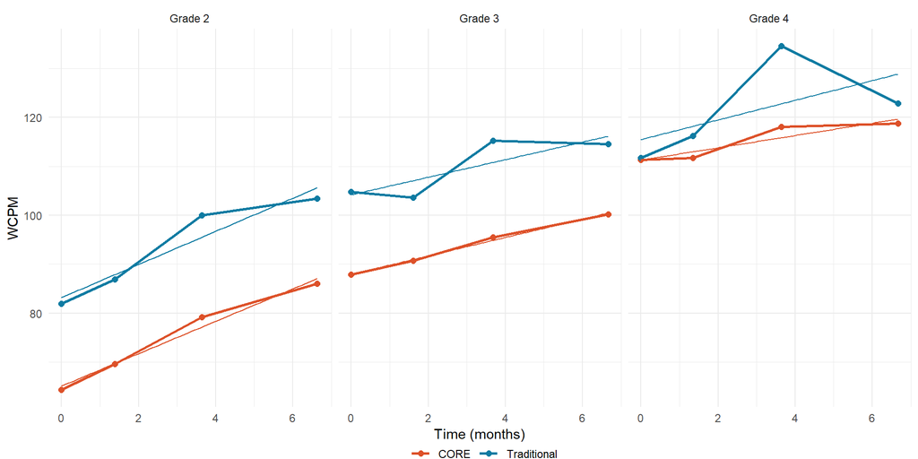

*Mean Standard Error of the Slope (*SEb*)*

| Grade | CORE Mean SEb | CORE SD | Traditional Mean SEb | Traditional SD | d |
| --- | --- | --- | --- | --- | --- |
| 2 | 2.82 | 2.36 | 3.93 | 3.04 | 0.41 |
| 3 | 2.88 | 2.36 | 4.32 | 3.38 | 0.55 |
| 4 | 3.16 | 2.46 | — | — | — |

*Reliability Estimates across Occasions*

[output not shown]

## We found

Model-based CORE scores

- more precise individual slope parameter estimates
- higher reliability at measurement occasions (LGM)
- latent slope means measured with less variance

### Conclusion

Model-based CORE scores may provide better data with which to make instructional decisions, such as risk status or responsiveness to instruction

## We also wanted to know

**CORE vs. Traditional ORF**

2. Which has better distal (fall) and proximal (spring) predictive performance:
- spring comprehension scores (easyCBM) Grades 2-4
- spring state reading test scores & proficiency Grades 3-4

## We found

Predictive framework, training/test data, 10-fold cross-validation, and OLS models

Across all comparisons - grade, outcome, loss function, and distal and proximal predictors

Model-based CORE scores:

- lower *RMSE*
- higher $R^2$ , sensitivity, specificity, and *AUC*

Model-based CORE scores had a stronger relation with year-end reading comprehension and state reading test scores than traditional ORF scores

## Conclusion

The **model-based CORE scores**, with a **stronger relation with important reading outcomes**, can potentially better help with **early identification** of at-risk students and potentially better help **monitor the ORF progress** of those at-risk students because the scores provide a **better estimate** of students’ current and prospective reading proficiency

## Summary

1. Evidence to support ASR scoring and shorter ORF passages [18]
2. Model-based WCPM scale scores have a lower *CSEM*, better suited for screening and progress monitoring, and thus better educational decisions [19]
3. CORE improved within-year growth properties and predictive performance, providing preliminary evidence for consequential assessment [20]

## Where are we going from here?

[CORE + Prosody](https://jnese.github.io/coreprosody/)

- Model-based ORF with accuracy, speed, **&** prosody
- Prosody estimate with machine learning
- Grant [R305A200018](https://ies.ed.gov/funding/grantsearch/details.asp?ID=3427)

Computational Tools for Model-Based ORF

- `R` package for model-based WCPM scores
- “testlet” model (sentences within passages)
- Grant [R305D200038](https://ies.ed.gov/funding/grantsearch/details.asp?ID=3410)

## Acknowledgements

[Dr. Aki Kamata](https://www.smu.edu/simmons/About-Us/Directory/Education-Policy-Leadership/Kamata)

[Dr. Cornelis Potgieter](https://cse.tcu.edu/mathematics/faculty-staff/view/nelis-potgieter)

[Dr. Yusuf Kara](https://www.smu.edu/simmons/About-Us/Directory/Center-On-Research-Evaluation/Kara)

## Questions?

jnese@uoregon.edu

*[slides will be posted [here](https://jnese.github.io/coreprosody/dissemination.html)]*

## References

[1]

N. R. P. (US), N. I. of Child Health, and H. D. (US), *Teaching children to read: An evidence-based assessment of the scientific research literature on reading and its implications for reading instruction: Reports of the subgroups*. National Institute of Child Health; Human Development, National …, 2000.

[2]

L. S. Fuchs, D. Fuchs, M. K. Hosp, and J. R. Jenkins, “Oral reading fluency as an indicator of reading competence: A theoretical, empirical, and historical analysis,” *Scientific studies of reading*, vol. 5, no. 3, pp. 239–256, 2001.

[3]

R. H. Good, K. A. Powell-Smith, M. Abbott, E. N. Dewey, A. N. Warnock, and D. VanLoo, “Examining the association between DIBELS next and the SBAC ELA achievement standard,” *Contemporary School Psychology*, vol. 23, no. 3, pp. 258–269, 2019.

[4]

J. R. Jenkins, L. S. Fuchs, P. Van Den Broek, C. Espin, and S. L. Deno, “Sources of individual differences in reading comprehension and reading fluency.” *Journal of educational psychology*, vol. 95, no. 4, p. 719, 2003.

[5]

J. F. T. Nese, B. J. Park, J. Alonzo, and G. Tindal, “Applied curriculum-based measurement as a predictor of high-stakes assessment: Implications for researchers and teachers,” *The Elementary School Journal*, vol. 111, no. 4, pp. 608–624, 2011.

[6]

S. G. Schilling, J. F. Carlisle, S. E. Scott, and J. Zeng, “Are fluency measures accurate predictors of reading achievement?” *The Elementary School Journal*, vol. 107, no. 5, pp. 429–448, 2007.

[7]

J. Shin and K. McMaster, “Relations between CBM (oral reading and maze) and reading comprehension on state achievement tests: A meta-analysis,” *Journal of school psychology*, vol. 73, pp. 131–149, 2019.

[8]

A. R. Hoffman, J. E. Jenkins, and S. K. Dunlap, “Using DIBELS: A survey of purposes and practices,” *Reading Psychology*, vol. 30, no. 1, pp. 1–16, 2009.

[9]

K. D. Cummings, G. Biancarosa, A. Schaper, and D. K. Reed, “Examiner error in curriculum-based measurement of oral reading,” *Journal of School Psychology*, vol. 52, no. 4, pp. 361–375, 2014.

[10]

S. Munir-McHill, T. Bousselot, K. Cummings, and J. Smith, “Profiles in school-level data-based decision making,” 2012.

[11]

D. K. Reed, K. D. Cummings, A. Schaper, and G. Biancarosa, “Assessment fidelity in reading intervention research: A synthesis of the literature,” *Review of Educational Research*, vol. 84, no. 2, pp. 275–321, 2014.

[12]

D. K. Reed and K. M. Sturges, “An examination of assessment fidelity in the administration and interpretation of reading tests,” *Remedial and Special Education*, vol. 34, no. 5, pp. 259–268, 2013.

[13]

D. J. Francis, K. L. Santi, C. Barr, J. M. Fletcher, A. Varisco, and B. R. Foorman, “Form effects on the estimation of students’ oral reading fluency using DIBELS,” *Journal of School Psychology*, vol. 46, no. 3, pp. 315–342, 2008.

[14]

T. J. Christ and B. Silberglitt, “Estimates of the standard error of measurement for curriculum-based measures of oral reading fluency,” *School Psychology Review*, vol. 36, no. 1, pp. 130–146, 2007.

[15]

B. C. Poncy, C. H. Skinner, and P. K. Axtell, “An investigation of the reliability and standard error of measurement of words read correctly per minute using curriculum-based measurement,” *Journal of Psychoeducational Assessment*, vol. 23, no. 4, pp. 326–338, 2005.

[16]

E. S. Shapiro, “Commentary on progress monitoring with CBM-r and decision making: Problems found and looking for solutions.” *Journal of School Psychology*, vol. 51, no. 1, pp. 59–66, 2012.

[17]

D. M. Williamson, X. Xi, and F. J. Breyer, “A framework for evaluation and use of automated scoring,” *Educational measurement: issues and practice*, vol. 31, no. 1, pp. 2–13, 2012.

[18]

J. F. Nese and A. Kamata, “Evidence for automated scoring and shorter passages of CBM-r in early elementary school.” *School Psychology*, vol. 36, no. 1, p. 47, 2021.

[19]

J. F. Nese and A. Kamata, “Addressing the large standard error of traditional CBM-r: Estimating the conditional standard error of a model-based estimate of CBM-r,” *Assessment for Effective Intervention*, vol. 47, no. 1, pp. 53–58, 2021.

[20]

J. F. T. Nese, “Comparing the growth and predictive performance of a traditional oral reading fluency measure with an experimental novel measure,” *AERA Open*, vol. 8, p. 23328584211071112, 2022.